# `lidR`: (A workshop for) Airborne lidar Data Manipulation and Visualization for Environmental Applications

Liam A.K. Irwin, Brent Murray, Nicholas C. Coops

## Presenters

- Liam A.K. Irwin - PhD Student
- Brent A. Murray - PhD Student
- Nicholas C. Coops - Professor

Integrated Remote Sensing Studio University of British Columbia Vancouver, Canada

[figure not shown]

## Overview

- **Li**ght **D**etection **a**nd **R**anging (lidar)
- The lidR package - a brief introduction
- Workshop overview

## What is lidar?

- **Li**ght **D**etection **a**nd **R**anging
- Active form of remote sensing
- Measures distance to target surfaces with millions of narrow light pulses
- Airborne laser scanning performs lidar systematically from aircraft or drones

## Lidar Data – Point Clouds

- Discrete returns are aggregated into point clouds (`.LAS/.LAZ`)
- Lidar points have three-dimensional (`XYZ`) coordinates, and other attributes (`Intensity`, `ReturnNumber`, etc…)
- Point clouds can be processed into vegetation structure summaries with **lidR**

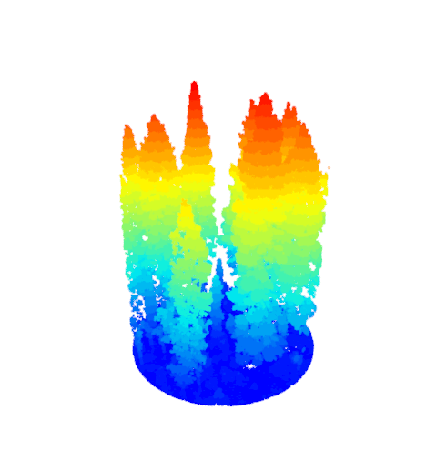

## lidR

- Written by `Jean-Romain Roussel`
- Package for `manipulating` and `visualizing` ALS data
- Written entirely open source within R-geospatial ecosystem (`terra`/`sf`)
- Most processes run efficiently with back-end `C++` code

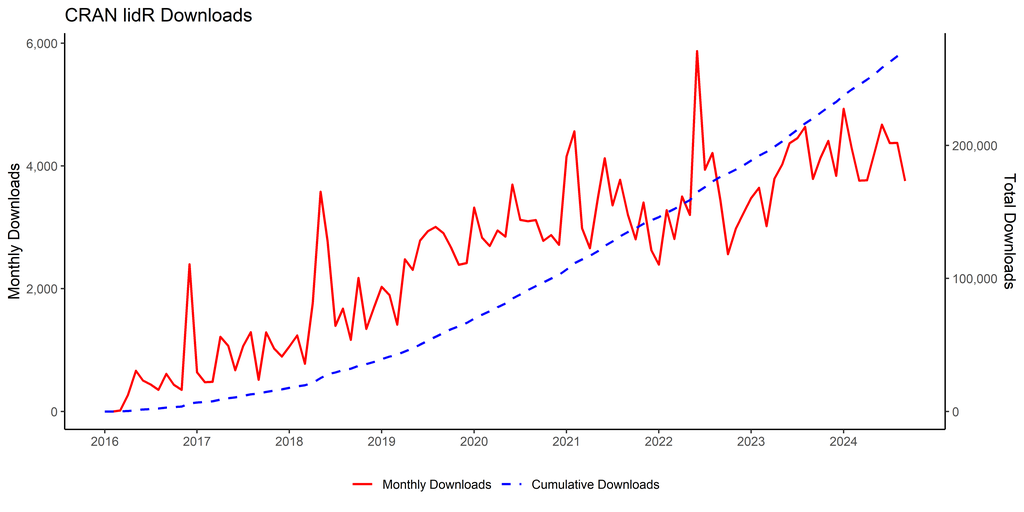

[figure not shown]

## r-lidar

- lidR author `Jean-Romain Roussel` is commited to maintaining the `lidR` package as fully open source
- He now runs `r-lidar`; a consulting and development company targeted at lidar applications
- Visit `r-lidar.com` for more information

[figure not shown]

## Workshop Outline

- Introduction to lidar and lidR (09:00)
- Reading LAS and LAZ files (09:10)
- Point Classification and filtering (9:15)
- Digital Terrain Models and Height Normalization (9:25)
- Canopy Height Models (9:35)
- lidar Summary Metrics (9:50)
- File Collection Processing Engine (10:10)

## Get Set Up!

https://liamirwin.github.io/LPS_lidRtutorial/

[figure not shown]